# Load packages

## Bar charts from summarized data

Suppose instead of beginning with subject level data, we begin with aggregated summaries.

```r
# Note the use of dplyr::rename to rename columns
demog.data.table.original <- data.frame(table(demog.data$REGION))
demog.data.table.renamed <- demog.data.table.original %>% rename(REGION = Var1)

demog.data.table.original
```

```
##             Var1 Freq
## 1   Asia/Pacific 1013
## 2 Eastern Europe 1098
## 3  North America 1224
## 4  South America  375
## 5 Western Europe 1290
```

```r
demog.data.table.renamed
```

```
##           REGION Freq
## 1   Asia/Pacific 1013
## 2 Eastern Europe 1098
## 3  North America 1224
## 4  South America  375
## 5 Western Europe 1290
```

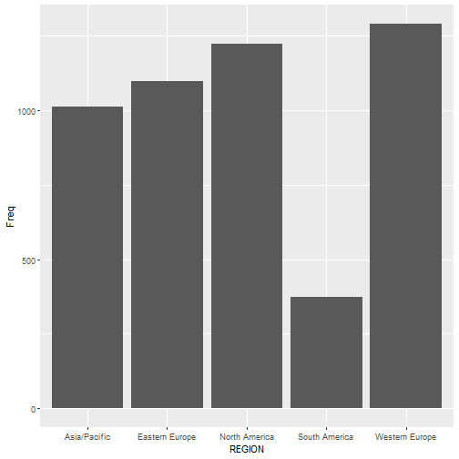

```r
ggplot(data=demog.data.table.renamed, aes(x=REGION, y=Freq)) + geom_bar(stat="identity")
```

## Suppose we want relative frequency bar chart

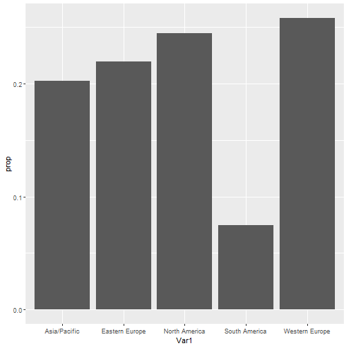

```r
demog.data.table.original$prop <- demog.data.table.original$Freq/sum(demog.data.table.original$Freq)
ggplot(data=demog.data.table.original, aes(x=Var1, y=prop)) + geom_bar(stat="identity")
```

Challenge: Manipulate the limits and tick marks so this graphic's y-axis extends to 0.3 and shows tick marks at 0, 0.025, 0.05, …, 0.30.

## A punched up version - barchart by region and gender

Items to note:

- ggplot2::aes links the color used to fill in bars to Var2 (SEX)
- ggplot2::geom_bar takes position = “dodge”, contrast this with the default: position=“stack”
- ggplot2::geom_text is employed to add frequency counts
- scales::percent_format is used to add % signs on axis. The scales packages is a good package to review!
- ggplot2::scale_fill_manual is used to manipulate the colors used to fill bars
- ggplot2::theme is used to manipulate the position of the legend

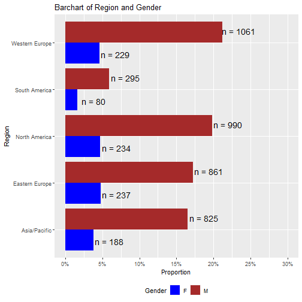

```r
demog.data.table <- data.frame(table(demog.data$REGION, demog.data$SEX))
demog.data.table$prop <- demog.data.table$Freq/sum(demog.data.table$Freq)

p1 <- ggplot(data = demog.data.table, aes(x = Var1, y = prop, fill = Var2)) +
  geom_bar(stat = "identity", position = "dodge") +
  coord_flip() +
  geom_text(position=position_dodge(width=1), size = 5,
             aes(y=prop+.02, label=paste(" n = ", Freq, sep = "")))+
  scale_y_continuous(limits = c(0,.3), breaks = seq(0,1,.05), labels = percent_format()) +
  scale_fill_manual(values = c("blue", "brown")) +
  labs(y = "Proportion", x = "Region", fill = "Gender", title="Barchart of Region and Gender")+
  theme(legend.position= "bottom")
p1
```

# Plotting parametric functions

## Base R approach

Here's base R's graphics::curve function in action. It provides a graphic and if assigned to an objects, returns a list.

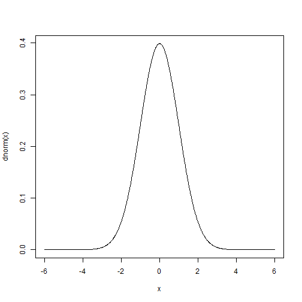

```r
curve(expr = dnorm(x), from=-6, to=6, n=1001)
temp <- curve(expr = dnorm(x), from=-6, to=6, n=1001)
```

```r
class(temp)
```

```
## [1] "list"
```

```r
str(temp)
```

```
## List of 2
##  $ x: num [1:1001] -6 -5.99 -5.98 -5.96 -5.95 ...
##  $ y: num [1:1001] 6.08e-09 6.53e-09 7.01e-09 7.54e-09 8.09e-09 ...
```

The list readily converts to a data.frame which is needed for a ggplot graphic.

```r
head(data.frame(temp))
```

[output not shown]

## the figuRes2::gcurve function

This function is a hack of the graphics::curve function. It suppresses graphic creation, returns a data.frame and optionally provides an additional column to the data.frame called 'category'.

```r
head(figuRes2::gcurve(expr = dnorm(x), from=-6, to=6, n=101, category="Standard Normal"))
```

```
##       x            y        category
## 1 -6.00 6.075883e-09 Standard Normal
## 2 -5.88 1.239294e-08 Standard Normal
## 3 -5.76 2.491643e-08 Standard Normal
## 4 -5.64 4.937910e-08 Standard Normal
## 5 -5.52 9.645989e-08 Standard Normal
## 6 -5.40 1.857362e-07 Standard Normal
```

By using multiple calls to gcurve and using dplyr::bind_rows we can quickly create graphics with multiple functions.

Note the use of color within ggplot2::aes.

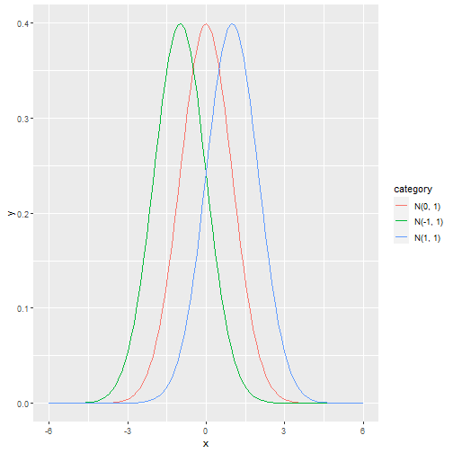

```r
my.df <- rbind(
  gcurve(expr = dnorm(x), from=-6, to=6, n=101, category="N(0, 1)"),
  gcurve(expr = dnorm(x, -1, 1), from=-6, to=6, n=101, category="N(-1, 1)"),
  gcurve(expr = dnorm(x, 1, 1), from=-6, to=6, n=101, category="N(1, 1)"))

ggplot(data=my.df, aes(x=x, y=y, color=category))+geom_line()
```

Here's a punched-up version:

- size = .75 is used within ggplot2::geom_line to manually control the line size
- y-label is suppressed by populating it with a blank character vector.
- the second graphics contrasts this by populated the y-labels with NULL
  - note how this increases with width of the figure
- the third graphic uses the argument breaks=NULL in ggplot2::scale_y_continuous to remove tick marks and axis labels. (This maybe helpful when comparing density curves. The y-axis may distract colleagues from appreciating that area under curves is 1 for probability density functions.)

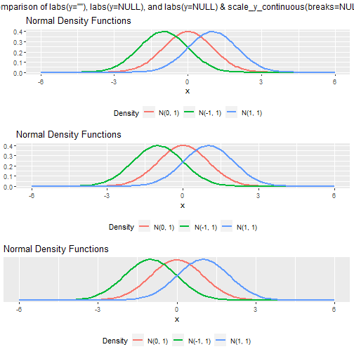

```r
grid.arrange(top='Comparison of labs(y=""), labs(y=NULL), and labs(y=NULL) & scale_y_continuous(breaks=NULL)',
ggplot(data=my.df, aes(x=x, y=y, color=category))+
  geom_line(size=.75)+
  labs(x="x", y="",
       title="Normal Density Functions",
       color="Density")+
  theme(legend.position="bottom"),

ggplot(data=my.df, aes(x=x, y=y, color=category))+
  geom_line(size=.75)+
  labs(x="x", y=NULL,
       title="Normal Density Functions",
       color="Density")+
  theme(legend.position="bottom"),
ggplot(data=my.df, aes(x=x, y=y, color=category))+
  geom_line(size=.75)+
  labs(x="x", y=NULL,
       title="Normal Density Functions",
       color="Density")+
  theme(legend.position="bottom")+
  scale_y_continuous(breaks=NULL)
)
```

# Histograms

Let's start from scratch:

```r
head(demog.data)
```

```
##       CENTREID SUBJID AGE SEX    TRTGRP         REGION HEIGHT WEIGHT DIABET
## 5699     60016  17380  58   M Treatment   Asia/Pacific    165   65.0      1
## 8622     67458  24040  62   M   Placebo Western Europe    181   88.0      0
## 11716    58401  30384  63   M   Placebo Western Europe    175   77.0      0
## 9633     57867  26373  63   F   Placebo Western Europe    159   81.4      0
## 13562    59286  34327  70   M Treatment Western Europe    160   81.3      1
## 4004     59512  13390  80   M Treatment   Asia/Pacific    151   62.0      0
##       SYSBP DIABP      BMI      BMI.GRP GFR.GRP HDLC        REGION2
## 5699    116    78 23.87511    <25 kg/m2    Mild 1.04   Asia/Pacific
## 8622    132    79 26.86121 25-<30 kg/m2    Mild 1.14 Western Europe
## 11716   140    81 25.14286 25-<30 kg/m2  Normal 1.83 Western Europe
## 9633    165   101 32.19809   >=30 kg/m2    Mild 1.82 Western Europe
## 13562   132    78 31.75781   >=30 kg/m2    Mild 1.30 Western Europe
## 4004    144    83 27.19179 25-<30 kg/m2    Mild 1.38   Asia/Pacific
##              REGION3
## 5699    Asia/Pacific
## 8622  Western Europe
## 11716 Western Europe
## 9633  Western Europe
## 13562 Western Europe
## 4004    Asia/Pacific
```

```r
str(demog.data)
```

```
## 'data.frame':    5000 obs. of  17 variables:
##  $ CENTREID: int  60016 67458 58401 57867 59286 59512 61504 59325 57028 60016 ...
##  $ SUBJID  : int  17380 24040 30384 26373 34327 13390 28260 18671 39222 17376 ...
##  $ AGE     : int  58 62 63 63 70 80 48 66 75 69 ...
##  $ SEX     : Factor w/ 2 levels "F","M": 2 2 2 1 2 2 2 1 1 2 ...
##  $ TRTGRP  : Factor w/ 2 levels "Placebo","Treatment": 2 1 1 1 2 2 1 1 2 1 ...
##  $ REGION  : Factor w/ 5 levels "Asia/Pacific",..: 1 5 5 5 5 1 2 1 3 1 ...
##  $ HEIGHT  : int  165 181 175 159 160 151 156 152 170 160 ...
##  $ WEIGHT  : num  65 88 77 81.4 81.3 62 75 57 79 62.7 ...
##  $ DIABET  : int  1 0 0 0 1 0 0 0 0 0 ...
##  $ SYSBP   : int  116 132 140 165 132 144 158 169 134 130 ...
##  $ DIABP   : int  78 79 81 101 78 83 99 92 86 70 ...
##  $ BMI     : num  23.9 26.9 25.1 32.2 31.8 ...
##  $ BMI.GRP : Factor w/ 4 levels "<25 kg/m2",">=30 kg/m2",..: 1 3 3 2 2 3 2 1 3 1 ...
##  $ GFR.GRP : Factor w/ 5 levels "Mild","Missing",..: 1 1 4 1 1 1 4 4 1 4 ...
##  $ HDLC    : num  1.04 1.14 1.83 1.82 1.3 1.38 1.34 1.76 1.75 1.53 ...
##  $ REGION2 : Factor w/ 5 levels "South America",..: 2 5 5 5 5 2 3 2 4 2 ...
##  $ REGION3 : Factor w/ 5 levels "Western Europe",..: 4 1 1 1 1 4 3 4 2 4 ...
```

```r
sort(names(demog.data))
```

```
##  [1] "AGE"      "BMI"      "BMI.GRP"  "CENTREID" "DIABET"   "DIABP"
##  [7] "GFR.GRP"  "HDLC"     "HEIGHT"   "REGION"   "REGION2"  "REGION3"
## [13] "SEX"      "SUBJID"   "SYSBP"    "TRTGRP"   "WEIGHT"
```

## Basic historgram

Here's a histogram from heights.

```
## Warning: Removed 12 rows containing non-finite values (stat_bin).
```

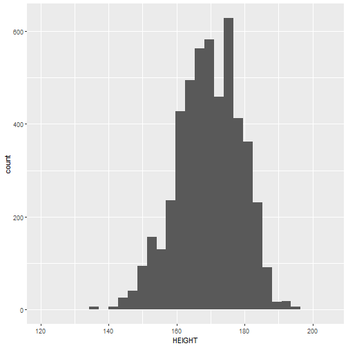

```r
ggplot(data=demog.data, aes(x=HEIGHT)) + geom_histogram()
```

```r
summary(demog.data$HEIGHT)
```

```
##    Min. 1st Qu.  Median    Mean 3rd Qu.    Max.    NA's
##   121.0   163.0   170.0   169.5   176.0   203.0      12
```

### Investigating the warning message

We see

```r
# note na.rm = T is needed
max(demog.data$HEIGHT, na.rm=T) - min(demog.data$HEIGHT, na.rm=T)
```

```
## [1] 82
```

```r
median(demog.data$HEIGHT)
```

```
## [1] NA
```

```r
mean(demog.data$HEIGHT)
```

```
## [1] NA
```

```r
median(demog.data$HEIGHT, na.rm=T)
```

```
## [1] 170
```

```r
mean(demog.data$HEIGHT, na.rm=T)
```

```
## [1] 169.4918
```

### binwidth options

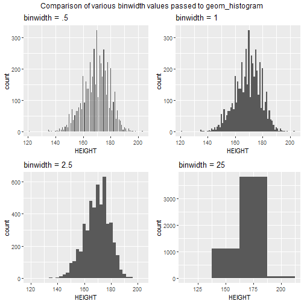

```r
grid.arrange(top="Comparison of various binwidth values passed to geom_histogram",
ggplot(data=demog.data, aes(x=HEIGHT)) + geom_histogram(binwidth = .5) + ggtitle("binwidth = .5"),
ggplot(data=demog.data, aes(x=HEIGHT)) + geom_histogram(binwidth = 1)+ ggtitle("binwidth = 1"),
ggplot(data=demog.data, aes(x=HEIGHT)) + geom_histogram(binwidth = 2.5)+ ggtitle("binwidth = 2.5"),
ggplot(data=demog.data, aes(x=HEIGHT)) + geom_histogram(binwidth = 25)+ ggtitle("binwidth = 25"),
ncol=2)
```